# Introducción a distribuciones de probabilidad

Ramon Ceballos

7/2/2021

# **Distribución de Binomial Negativa**

## 1. Conceptos teóricos y matemáticos

Si **$X$** es una variable aleatoria que mide el “número de repeticiones hasta observar los **$r$** éxitos (nº determinado de éxitos) en ensayos de Bernoulli”. Diremos que **$X$** se distribuye como una Binomial Negativa con parámetros **$r$** y **$p$**.

$$X\sim\text{BN}(r,p)$$

En esta expresión, $p$ es la probabilidad de éxito. Se determina el nº de éxitos, por ello el global será k-1.

Vamos a definir algunas de las propiedades que tendrá una distribución Binomial Negativa.

- El **dominio** de $X$ será $D_X = \{r, r+1, r+2,\dots\}$. Partimos de $r$ que es el nº de éxitos que se quiere obtener.
- La **función de probabilidad** vendrá dada por:
  $$f(k) = {k-1\choose r-1}p^r(1-p)^{k-r}, k\geq r$$

Es un ajuste de la función de probabilidad de una binomial. El dominio debe de ser mayor o igual que el nº de exitos.

- La **función de distribución** no tiene una expresión analítica.
- **Esperanza**. $E(X) = \frac{r}{p}$.
- **Varianza**. $Var(X) = r\frac{1-p}{p^2}$.

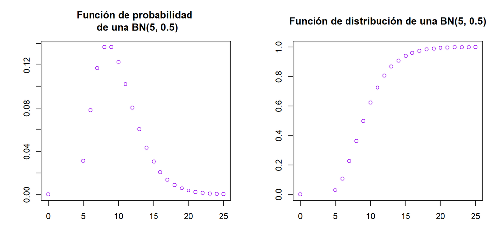

```r
par(mfrow = c(1,2))

#5 exitos en 20 intentos
exitos = 5
size = 20

#Función de probabilidad
plot(c(rep(0,exitos),exitos:(size+exitos)),
     c(rep(0,exitos),dnbinom(0:size,exitos,0.5)),
     col = "purple",
     xlab = "", ylab = "",
     main = "Función de probabilidad \n de una BN(5, 0.5)")

#Función de distribución
plot(c(rep(0,exitos),exitos:(size+exitos)),
     c(rep(0,exitos),pnbinom(0:size,exitos,0.5)),
     col = "purple",
     xlab = "", ylab = "",
     main = "Función de distribución de una BN(5, 0.5)")
```

```r
par(mfrow= c(1,1))
```

Ejemplo: caja de cerillas de Banach (se coloca una caja de cerillas en cada bolsillo y elegía aleatoriamente hasta agotar las cajas); tenemos dos cajetillas de tabaco y vamos seleccionando aleatoriamente los cigarrillo y al acabar una d elas dos cajas ver cuál es el nº esperado.

## 2. Distribución Binomial Negativa en `R` y `Python`

El código de la distribución Binomial Negativa:

- En **`R`** tenemos las funciones del paquete `Rlab`: **`dnbinom(x, size, prop), pnbinom(q, size, prop), qnbinom(p, size, prop), rnbinom(n, size, prop)`** donde `size` es el número de casos exitosos y `prob` la probabilidad del éxito.
- En **`Python`** tenemos las funciones del paquete **`scipy.stats.nbinom`**: **`pmf(k,n,p), cdf(k,n,p), ppf(q,n,p), rvs(n,p)`** donde `n` es el número de casos exitosos y `p` la probabilidad del éxito.

## 3. Ejemplos en código para la distribución Binomial Negativa (R y Python)

#### **Ejemplo en R**

Empleamos las funciones anteriores.

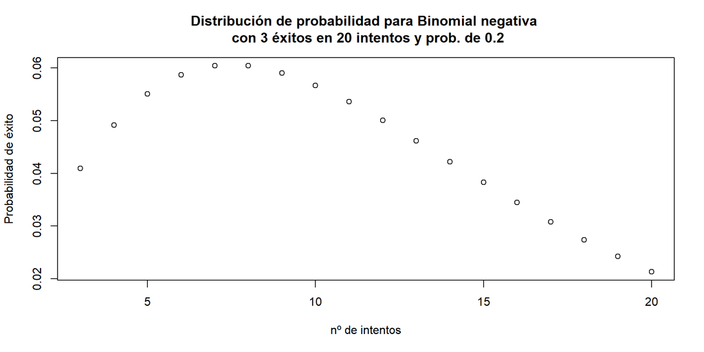

```r
#defino los parámetros de la distr. bin. neg.
n = 20 #nº de intentos
r = 3 #nº éxitos
p = 0.2 #probabilidad

#Defino la función de probabilidad para Binomial negativa
plot(r:n, dnbinom(x=r:n,size = r,prob=p),
     title("Distribución de probabilidad para Binomial negativa \n con 3 éxitos en 20 intentos y prob. de 0.2"),
     xlab = "nº de intentos",
     ylab = "Probabilidad de éxito")
```

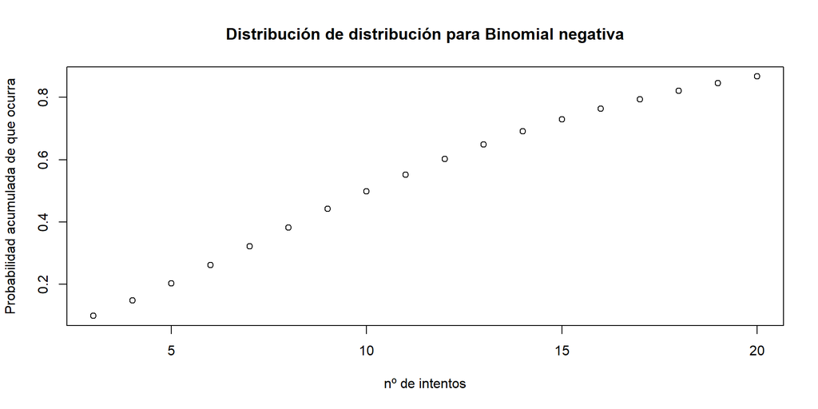

```r
#Defino la función de distribución para Binomial negativa
plot(r:n,pnbinom(q=r:n, size = r,prob = p),
     title("Distribución de distribución para Binomial negativa"),
     xlab = "nº de intentos",
     ylab = "Probabilidad acumulada de que ocurra")
```

```r
#La mediana
qnbinom(p=0.5,size=r,prob = p)
```

```
## [1] 11
```

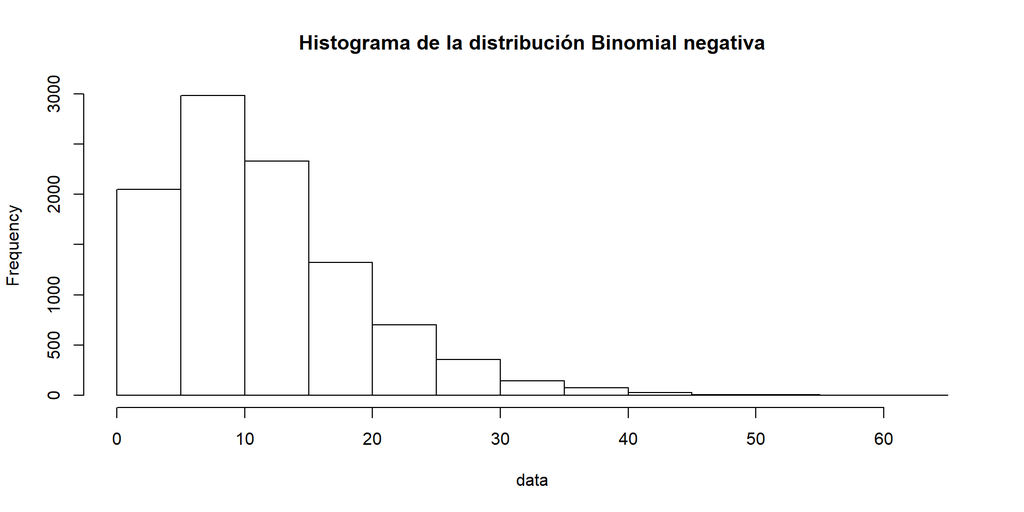

```r
#Genero datos aleatorios con Binomial negativa
rnbinom(10000,size=r,prob=0.2) -> data
#Represento el histograma de los datos aleatorios
hist(data, breaks = n,
     main="Histograma de la distribución Binomial negativa")
```

#### **Ejemplo en Python**

Vete al script de Python del presente tema 10.